# IE 360 - HW 2

Nergiz Selin Angın

11 05 2022

# Introduction & Problem Description

The data which is called “UGSdata” in the homework, contains quarterly gasoline and diesel sales (in 1000 m3) of a major distributor between 2000 and 2006, and a number of potential independent variables. These variables are summarized as follows:  
UGS: Unleaded gasoline sale in a given quarter,  
RNUV: An index indicating the rate of new unleaded gasoline using vehicles being added to the traffic in a quarter,  
PU: Average price (adjusted with an index) of a liter of unleaded gasoline in a quarter,  
PG: Average price (adjusted with an index) of a liter of diesel gasoline in a quarter,  
NUGV: Number of unleaded gasoline using vehicles in the traffic,  
NDGV: Number of diesel gasoline using vehicles in the traffic (per 1000 people),  
GNPA: Agriculture component of Gross National Product (adjusted with an index),  
GNPC: Commerce component of Gross National Product (adjusted with an index),  
NLPG: Number of LPG using vehicles in the traffic,  
GNP: Grand total for GNP (agriculture, commerce and other components total).

The aim of this homework is to forecast the sales of UGS for every quarter of 2007 by using time series regression methods.

# Required Packages and Data

```r
library(fpp)
library(fpp2)
library(ggplot2)
library(data.table)
library(readxl)
library(skimr)
library(janitor)
library(readr)
library(tidyverse)
library(fBasics)
library(dplyr)
library(writexl)
library(scales)
library(plyr)
library(zoo)
library(lubridate)
library(ggplot2)
library(forecast)
library(corrplot)
library(ggcorrplot)
library(xts)

UGSdata<- read.csv("IE360_Spring22_HW2_data.csv")
sapply(UGSdata, class)
```

```
##                               Quarter          Unleaded.Gasoline.Sale..UGS.
##                           "character"                           "character"
##                                  RNUV                X..LPG.Vehicles..NLPG.
##                             "numeric"                           "character"
##       Price.of.Unleaded.Gasoline..PU.         Price.of.Diesel.Gasoline..PG.
##                             "numeric"                             "numeric"
##  X..Unleaded.Gasoline.Vehicles..NUGV. X..of.Diesel.Gasoline.Vehicles..NDGV.
##                           "character"                             "numeric"
##                       GNP.Agriculture                          GNP.Commerce
##                           "character"                           "character"
##                             GNP.Total
##                           "character"
```

```r
UGSdata$Unleaded.Gasoline.Sale..UGS. <- as.numeric(gsub(" ","",UGSdata$Unleaded.Gasoline.Sale..UGS.))
UGSdata$X..Unleaded.Gasoline.Vehicles..NUGV. <- as.numeric(gsub(" ","",UGSdata$X..Unleaded.Gasoline.Vehicles..NUGV.))
UGSdata$X..LPG.Vehicles..NLPG. <- as.numeric(gsub(" ","",UGSdata$X..LPG.Vehicles..NLPG.))
UGSdata$GNP.Commerce <- as.numeric(gsub(" ","",UGSdata$GNP.Commerce ))
UGSdata$GNP.Total <- as.numeric(gsub(" ","",UGSdata$GNP.Total ))
UGSdata$GNP.Agriculture <- as.numeric(gsub(" ","",UGSdata$GNP.Agriculture  ))
UGSdata$Quarter <- as.yearqtr(UGSdata$Quarter, format = "%Y_Q%q")
```

### 1. Time Series Data of Unleaded Gasoline Sales (in 1000 m3) of a Major Distributor Between 2000 and 2006

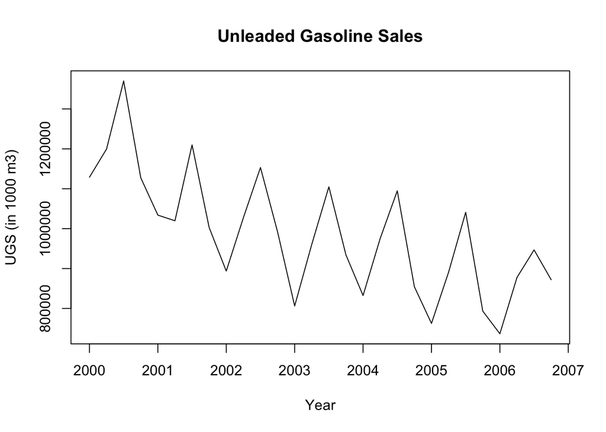

```r
time_series_UGS<- UGSdata[-c(29,30,31,32),]
time_series_UGS<- ts(time_series_UGS$Unleaded.Gasoline.Sale..UGS.,frequency = 4,start=c(2000,1))
ts.plot(time_series_UGS,xlab = "Year", ylab = "UGS (in 1000 m3)",main="Unleaded Gasoline Sales")
```

```r
Box.test(time_series_UGS, lag=10, type="Ljung-Box")
```

```
##
##  Box-Ljung test
##
## data:  time_series_UGS
## X-squared = 33.633, df = 10, p-value = 0.000213
```

When we look at the unleaded gasoline sales time series plot, we see that the data periodically peaks in about the seventh or eighth months. This means that the data contains seasonality. Besides, data has followed a decreasing trend over the years which means that the data is not stationary with respect to its mean. Also, when we do a Ljung–Box Q test (lag=10), we see that the data is not stationary. On the other hand, when the variance of the time series is analyzed, it can be observed that it does not change with time. This means that the data is stationary with respect to its variance.

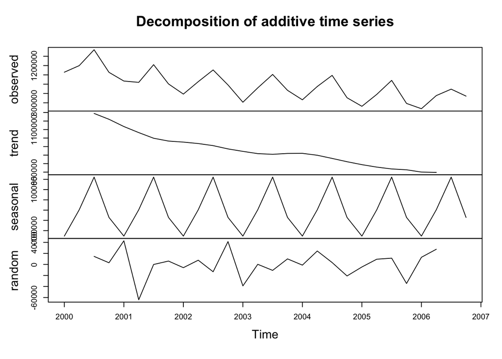

```r
decopm_data<- decompose(time_series_UGS,type="additive")
plot(decopm_data)
```

The decomposition of the time series data clearly shows the trend and seasonality.

### 2. Autocorrelation Functions of the Time Series Unleaded Gasoline Sales

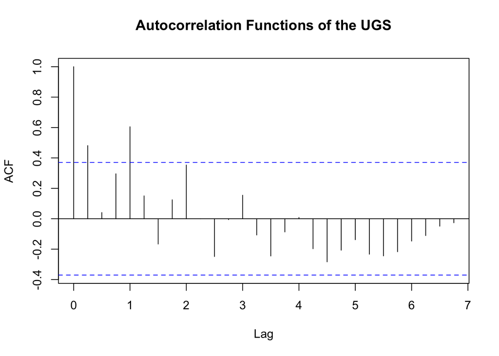

```r
acf(time_series_UGS, main="Autocorrelation Functions of the UGS",lag=28)
```

When we look at the autocorrelation function of the data up to lag 28, we see that the autocorrelation in lag 1 and the autocorrelation in lag 4 are more than critical values. Autocorrelation in lag 1 shows that sales are correlated with sales in the previous quarter and the autocorrelation in lag 4 indicates quarterly seasonality. Based on these, we can conclude that we may use lag 1 and lag 4 of the sales as variables in our time series regression model.

### 3. Seasonality, Trend and Lagged Variables

```r
UGSdata$quarters <- rep(1:4,8)
trend_variable <- 1:32
UGSdata$trend_variable <- trend_variable
UGSdata$lag1_UGS <- NA
UGSdata$lag4_UGS <- NA
for(i in 1:28){
 UGSdata$lag1_UGS[i+1] = UGSdata$Unleaded.Gasoline.Sale..UGS.[i]
}
for(i in 1:28){
UGSdata$lag4_UGS[i+4] = UGSdata$Unleaded.Gasoline.Sale..UGS.[i]
}
```

Trend, seasonality, lag1 of UGS and lag4 of UGS variables are added to the data, which can then be used in the regression model.

### 4. Regression Models

#### 4.1 Correlation of the Variables

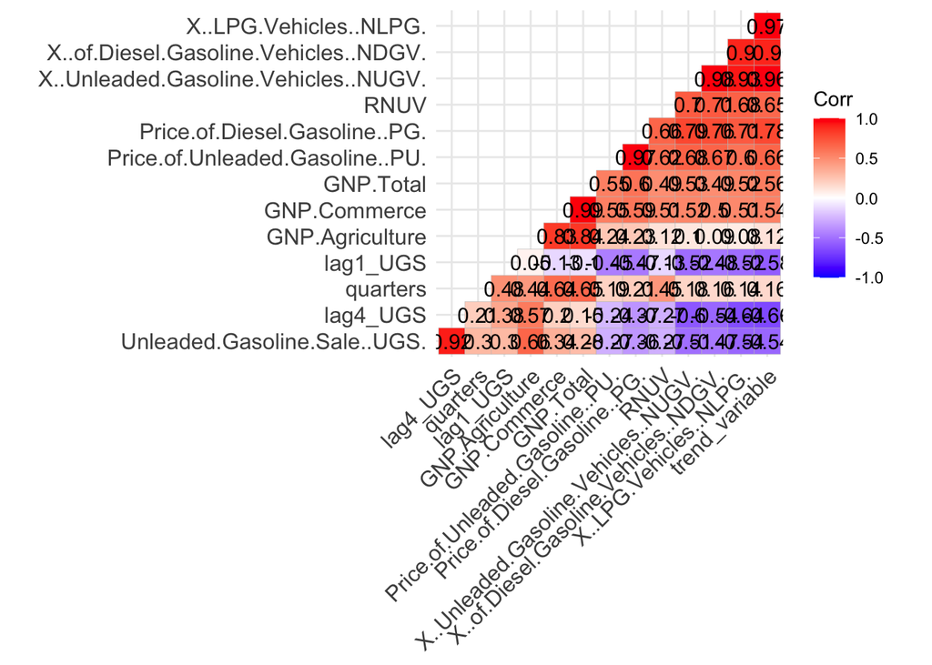

```r
corr_data <- UGSdata[!is.na(UGSdata$Unleaded.Gasoline.Sale..UGS. & UGSdata$lag1_UGS & UGSdata$lag4_UGS),]
corr_info = cor(corr_data[,unlist(lapply(corr_data, is.numeric))])
ggcorrplot(corr_info,
           hc.order = TRUE,
           type='lower',
           lab=TRUE)
```

The correlation of variables with each other is important for choosing which variable to use in the model. When we examine the correlation of variables, we find that the correlation of Lag4_UGS and UGS is quite high. This is a sign that we may use lag4_UGS in our regression model.

#### 4.2 Alternative Regression Models

```r
tr_data<- UGSdata[-c(29,30,31,32),-1]
tr_data$quarters<-as.character(tr_data$quarters)

model1 <-lm(Unleaded.Gasoline.Sale..UGS. ~.,tr_data)
summary(model1)
```

```
##
## Call:
## lm(formula = Unleaded.Gasoline.Sale..UGS. ~ ., data = tr_data)
##
## Residuals:
##    Min     1Q Median     3Q    Max
## -38364  -9454   -409   7421  33438
##
## Coefficients:
##                                         Estimate Std. Error t value Pr(>|t|)
## (Intercept)                            4.986e+06  2.057e+06   2.424   0.0416 *
## RNUV                                   3.504e+06  3.001e+06   1.168   0.2766
## X..LPG.Vehicles..NLPG.                -5.564e-01  2.999e-01  -1.855   0.1007
## Price.of.Unleaded.Gasoline..PU.        8.635e+02  1.604e+03   0.538   0.6049
## Price.of.Diesel.Gasoline..PG.         -2.634e+03  2.381e+03  -1.106   0.3008
## X..Unleaded.Gasoline.Vehicles..NUGV.  -1.521e+00  8.887e-01  -1.712   0.1253
## X..of.Diesel.Gasoline.Vehicles..NDGV.  1.718e+04  9.680e+03   1.775   0.1139
## GNP.Agriculture                       -4.690e-02  6.735e-02  -0.696   0.5059
## GNP.Commerce                           1.273e-01  1.153e-01   1.104   0.3016
## GNP.Total                             -1.510e-02  2.391e-02  -0.631   0.5454
## quarters2                              3.018e+04  1.048e+05   0.288   0.7807
## quarters3                              4.411e+05  4.018e+05   1.098   0.3042
## quarters4                              1.900e+05  1.179e+05   1.611   0.1458
## trend_variable                         2.338e+04  2.579e+04   0.907   0.3911
## lag1_UGS                              -5.164e-01  3.120e-01  -1.655   0.1364
## lag4_UGS                              -8.342e-02  2.660e-01  -0.314   0.7618
## ---
## Signif. codes:  0 '***' 0.001 '**' 0.01 '*' 0.05 '.' 0.1 ' ' 1
##
## Residual standard error: 29960 on 8 degrees of freedom
##   (4 observations deleted due to missingness)
## Multiple R-squared:  0.9796, Adjusted R-squared:  0.9414
## F-statistic: 25.63 on 15 and 8 DF,  p-value: 4.113e-05
```

Creating a regression model has started with a large model that uses all variables, and we will try to find the best model by removing the insignificant variables.

```r
model2 <-lm(Unleaded.Gasoline.Sale..UGS. ~.-lag4_UGS,tr_data)
summary(model2)
```

```
##
## Call:
## lm(formula = Unleaded.Gasoline.Sale..UGS. ~ . - lag4_UGS, data = tr_data)
##
## Residuals:
##    Min     1Q Median     3Q    Max
## -35851 -10642   1917   7684  35880
##
## Coefficients:
##                                         Estimate Std. Error t value Pr(>|t|)
## (Intercept)                            4.716e+06  1.772e+06   2.661   0.0260 *
## RNUV                                   3.094e+06  2.562e+06   1.207   0.2580
## X..LPG.Vehicles..NLPG.                -5.599e-01  2.843e-01  -1.969   0.0804 .
## Price.of.Unleaded.Gasoline..PU.        9.776e+02  1.481e+03   0.660   0.5259
## Price.of.Diesel.Gasoline..PG.         -2.780e+03  2.214e+03  -1.256   0.2409
## X..Unleaded.Gasoline.Vehicles..NUGV.  -1.411e+00  7.746e-01  -1.822   0.1018
## X..of.Diesel.Gasoline.Vehicles..NDGV.  1.580e+04  8.182e+03   1.931   0.0855 .
## GNP.Agriculture                       -4.277e-02  6.265e-02  -0.683   0.5120
## GNP.Commerce                           1.447e-01  9.598e-02   1.507   0.1660
## GNP.Total                             -1.787e-02  2.108e-02  -0.848   0.4185
## quarters2                              1.179e+04  8.238e+04   0.143   0.8894
## quarters3                              3.830e+05  3.381e+05   1.133   0.2866
## quarters4                              1.712e+05  9.642e+04   1.776   0.1095
## trend_variable                         2.410e+04  2.437e+04   0.989   0.3485
## lag1_UGS                              -5.072e-01  2.946e-01  -1.722   0.1192
## ---
## Signif. codes:  0 '***' 0.001 '**' 0.01 '*' 0.05 '.' 0.1 ' ' 1
##
## Residual standard error: 28420 on 9 degrees of freedom
##   (4 observations deleted due to missingness)
## Multiple R-squared:  0.9794, Adjusted R-squared:  0.9473
## F-statistic: 30.51 on 14 and 9 DF,  p-value: 7.428e-06
```

In the previous model, lag4_UGS was the most insignificant variable, so it is removed from the model.

```r
model3 <-lm(Unleaded.Gasoline.Sale..UGS. ~.-lag4_UGS-GNP.Agriculture,tr_data)
summary(model3)
```

```
##
## Call:
## lm(formula = Unleaded.Gasoline.Sale..UGS. ~ . - lag4_UGS - GNP.Agriculture,
##     data = tr_data)
##
## Residuals:
##    Min     1Q Median     3Q    Max
## -36297  -7293   1229   6328  40320
##
## Coefficients:
##                                         Estimate Std. Error t value Pr(>|t|)
## (Intercept)                            4.279e+06  1.608e+06   2.662   0.0238 *
## RNUV                                   2.528e+06  2.359e+06   1.072   0.3090
## X..LPG.Vehicles..NLPG.                -4.437e-01  2.215e-01  -2.003   0.0730 .
## Price.of.Unleaded.Gasoline..PU.        5.654e+02  1.316e+03   0.430   0.6766
## Price.of.Diesel.Gasoline..PG.         -1.990e+03  1.837e+03  -1.084   0.3040
## X..Unleaded.Gasoline.Vehicles..NUGV.  -1.224e+00  7.049e-01  -1.737   0.1131
## X..of.Diesel.Gasoline.Vehicles..NDGV.  1.406e+04  7.563e+03   1.859   0.0927 .
## GNP.Commerce                           1.428e-01  9.334e-02   1.530   0.1571
## GNP.Total                             -2.136e-02  1.990e-02  -1.074   0.3082
## quarters2                             -3.068e+03  7.730e+04  -0.040   0.9691
## quarters3                              1.903e+05  1.812e+05   1.050   0.3182
## quarters4                              1.580e+05  9.190e+04   1.720   0.1163
## trend_variable                         1.477e+04  1.963e+04   0.753   0.4691
## lag1_UGS                              -5.973e-01  2.563e-01  -2.330   0.0420 *
## ---
## Signif. codes:  0 '***' 0.001 '**' 0.01 '*' 0.05 '.' 0.1 ' ' 1
##
## Residual standard error: 27650 on 10 degrees of freedom
##   (4 observations deleted due to missingness)
## Multiple R-squared:  0.9783, Adjusted R-squared:  0.9501
## F-statistic: 34.67 on 13 and 10 DF,  p-value: 1.501e-06
```

The insignificant variable “GNP.Agriculture” has been removed from model-2. We see that the adjusted R-squared increased.

```r
model4 <-lm(Unleaded.Gasoline.Sale..UGS. ~.-lag4_UGS-GNP.Agriculture-Price.of.Diesel.Gasoline..PG.,tr_data)
summary(model4)
```

```
##
## Call:
## lm(formula = Unleaded.Gasoline.Sale..UGS. ~ . - lag4_UGS - GNP.Agriculture -
##     Price.of.Diesel.Gasoline..PG., data = tr_data)
##
## Residuals:
##    Min     1Q Median     3Q    Max
## -42128 -10475  -1303  10034  39754
##
## Coefficients:
##                                         Estimate Std. Error t value Pr(>|t|)
## (Intercept)                            4.412e+06  1.616e+06   2.730  0.01956 *
## RNUV                                   2.300e+06  2.368e+06   0.971  0.35222
## X..LPG.Vehicles..NLPG.                -3.398e-01  2.013e-01  -1.688  0.11945
## Price.of.Unleaded.Gasoline..PU.       -8.377e+02  2.382e+02  -3.516  0.00483 **
## X..Unleaded.Gasoline.Vehicles..NUGV.  -1.342e+00  7.019e-01  -1.912  0.08225 .
## X..of.Diesel.Gasoline.Vehicles..NDGV.  1.560e+04  7.486e+03   2.084  0.06124 .
## GNP.Commerce                           7.612e-02  7.075e-02   1.076  0.30499
## GNP.Total                             -1.280e-02  1.840e-02  -0.695  0.50124
## quarters2                              4.158e+04  6.592e+04   0.631  0.54103
## quarters3                              2.606e+05  1.705e+05   1.528  0.15474
## quarters4                              1.946e+05  8.616e+04   2.258  0.04521 *
## trend_variable                         9.997e+03  1.928e+04   0.519  0.61432
## lag1_UGS                              -6.036e-01  2.583e-01  -2.337  0.03938 *
## ---
## Signif. codes:  0 '***' 0.001 '**' 0.01 '*' 0.05 '.' 0.1 ' ' 1
##
## Residual standard error: 27870 on 11 degrees of freedom
##   (4 observations deleted due to missingness)
## Multiple R-squared:  0.9757, Adjusted R-squared:  0.9493
## F-statistic: 36.88 on 12 and 11 DF,  p-value: 4.058e-07
```

“Price.of.Unleaded.Gasoline..PU.” variable is the most insignificant variable in the model-3. However, since price of the unleaded gasoline effect should be high in sales of unleaded gasoline , we removed the “Price.of.Diesel.Gasoline..PG.” variable in model-4, which has a quite high correlation with “Price.of.Unleaded.Gasoline..PU.”.

```r
model5 <-lm(Unleaded.Gasoline.Sale..UGS. ~.-lag4_UGS-GNP.Agriculture-Price.of.Diesel.Gasoline..PG.-GNP.Total,tr_data)
summary(model5)
```

```
##
## Call:
## lm(formula = Unleaded.Gasoline.Sale..UGS. ~ . - lag4_UGS - GNP.Agriculture -
##     Price.of.Diesel.Gasoline..PG. - GNP.Total, data = tr_data)
##
## Residuals:
##    Min     1Q Median     3Q    Max
## -38282 -11866   1100  14299  40444
##
## Coefficients:
##                                         Estimate Std. Error t value Pr(>|t|)
## (Intercept)                            4.306e+06  1.574e+06   2.736  0.01806 *
## RNUV                                   2.708e+06  2.244e+06   1.207  0.25082
## X..LPG.Vehicles..NLPG.                -3.169e-01  1.943e-01  -1.632  0.12871
## Price.of.Unleaded.Gasoline..PU.       -8.910e+02  2.207e+02  -4.038  0.00165 **
## X..Unleaded.Gasoline.Vehicles..NUGV.  -1.355e+00  6.865e-01  -1.973  0.07195 .
## X..of.Diesel.Gasoline.Vehicles..NDGV.  1.611e+04  7.289e+03   2.210  0.04731 *
## GNP.Commerce                           4.846e-02  5.723e-02   0.847  0.41373
## quarters2                              2.652e+04  6.090e+04   0.435  0.67098
## quarters3                              1.900e+05  1.341e+05   1.417  0.18187
## quarters4                              1.649e+05  7.319e+04   2.253  0.04379 *
## trend_variable                         5.295e+03  1.766e+04   0.300  0.76943
## lag1_UGS                              -6.655e-01  2.371e-01  -2.807  0.01585 *
## ---
## Signif. codes:  0 '***' 0.001 '**' 0.01 '*' 0.05 '.' 0.1 ' ' 1
##
## Residual standard error: 27270 on 12 degrees of freedom
##   (4 observations deleted due to missingness)
## Multiple R-squared:  0.9747, Adjusted R-squared:  0.9515
## F-statistic:    42 on 11 and 12 DF,  p-value: 7.536e-08
```

Although the p-value of the trend variable and some of the seasonality variables turn out to be too high in the model-4 (which indicates insignificance of the variables), the trend and seasonality are clearly observed in time series data. Because of this, it would be unreasonable to remove the trend and seasonality variables from the model. Model-5 was created by subtracting the variable with the highest p-value (GNP.Total) after the trend and seasonality variables from model-4. We observe that the adjusted R-squared increased.

```r
model6 <-lm(Unleaded.Gasoline.Sale..UGS. ~.-lag4_UGS-GNP.Agriculture-Price.of.Diesel.Gasoline..PG.-GNP.Total-GNP.Commerce,tr_data)
summary(model6)
```

```
##
## Call:
## lm(formula = Unleaded.Gasoline.Sale..UGS. ~ . - lag4_UGS - GNP.Agriculture -
##     Price.of.Diesel.Gasoline..PG. - GNP.Total - GNP.Commerce,
##     data = tr_data)
##
## Residuals:
##    Min     1Q Median     3Q    Max
## -40652  -8923  -1317  14160  32020
##
## Coefficients:
##                                         Estimate Std. Error t value Pr(>|t|)
## (Intercept)                            5.005e+06  1.325e+06   3.776 0.002309
## RNUV                                   2.592e+06  2.216e+06   1.170 0.263054
## X..LPG.Vehicles..NLPG.                -3.681e-01  1.826e-01  -2.016 0.064975
## Price.of.Unleaded.Gasoline..PU.       -8.397e+02  2.099e+02  -4.001 0.001509
## X..Unleaded.Gasoline.Vehicles..NUGV.  -1.680e+00  5.621e-01  -2.989 0.010451
## X..of.Diesel.Gasoline.Vehicles..NDGV.  1.947e+04  6.041e+03   3.224 0.006659
## quarters2                              7.253e+04  2.718e+04   2.668 0.019326
## quarters3                              3.024e+05  1.838e+04  16.457 4.38e-10
## quarters4                              2.148e+05  4.295e+04   5.000 0.000243
## trend_variable                         1.547e+04  1.280e+04   1.208 0.248435
## lag1_UGS                              -5.853e-01  2.150e-01  -2.722 0.017430
##
## (Intercept)                           **
## RNUV
## X..LPG.Vehicles..NLPG.                .
## Price.of.Unleaded.Gasoline..PU.       **
## X..Unleaded.Gasoline.Vehicles..NUGV.  *
## X..of.Diesel.Gasoline.Vehicles..NDGV. **
## quarters2                             *
## quarters3                             ***
## quarters4                             ***
## trend_variable
## lag1_UGS                              *
## ---
## Signif. codes:  0 '***' 0.001 '**' 0.01 '*' 0.05 '.' 0.1 ' ' 1
##
## Residual standard error: 26970 on 13 degrees of freedom
##   (4 observations deleted due to missingness)
## Multiple R-squared:  0.9732, Adjusted R-squared:  0.9525
## F-statistic: 47.15 on 10 and 13 DF,  p-value: 1.474e-08
```

Model-6 was created by subtracting the variable with the highest p-value (GNP.Commerce) after the trend and seasonality variables from model-5. We observe that the adjusted R-squared increased.

```r
model7 <-lm(Unleaded.Gasoline.Sale..UGS. ~.-lag4_UGS-GNP.Agriculture-Price.of.Diesel.Gasoline..PG.-GNP.Total-GNP.Commerce-RNUV,tr_data)
summary(model7)
```

```
##
## Call:
## lm(formula = Unleaded.Gasoline.Sale..UGS. ~ . - lag4_UGS - GNP.Agriculture -
##     Price.of.Diesel.Gasoline..PG. - GNP.Total - GNP.Commerce -
##     RNUV, data = tr_data)
##
## Residuals:
##    Min     1Q Median     3Q    Max
## -43432 -14735  -2217  14303  42518
##
## Coefficients:
##                                         Estimate Std. Error t value Pr(>|t|)
## (Intercept)                            4.452e+06  1.254e+06   3.549  0.00321
## X..LPG.Vehicles..NLPG.                -2.962e-01  1.742e-01  -1.700  0.11117
## Price.of.Unleaded.Gasoline..PU.       -7.284e+02  1.895e+02  -3.844  0.00179
## X..Unleaded.Gasoline.Vehicles..NUGV.  -1.521e+00  5.525e-01  -2.753  0.01556
## X..of.Diesel.Gasoline.Vehicles..NDGV.  1.801e+04  5.988e+03   3.008  0.00940
## quarters2                              8.564e+04  2.509e+04   3.413  0.00420
## quarters3                              3.043e+05  1.855e+04  16.401 1.55e-10
## quarters4                              2.111e+05  4.340e+04   4.864  0.00025
## trend_variable                         1.183e+04  1.258e+04   0.941  0.36282
## lag1_UGS                              -5.061e-01  2.067e-01  -2.448  0.02814
##
## (Intercept)                           **
## X..LPG.Vehicles..NLPG.
## Price.of.Unleaded.Gasoline..PU.       **
## X..Unleaded.Gasoline.Vehicles..NUGV.  *
## X..of.Diesel.Gasoline.Vehicles..NDGV. **
## quarters2                             **
## quarters3                             ***
## quarters4                             ***
## trend_variable
## lag1_UGS                              *
## ---
## Signif. codes:  0 '***' 0.001 '**' 0.01 '*' 0.05 '.' 0.1 ' ' 1
##
## Residual standard error: 27320 on 14 degrees of freedom
##   (4 observations deleted due to missingness)
## Multiple R-squared:  0.9703, Adjusted R-squared:  0.9513
## F-statistic:  50.9 on 9 and 14 DF,  p-value: 3.735e-09
```

Model-7 was created by subtracting the variable with the highest p-value (RNUV) from model-6. We observe that the adjusted R-squared slightly decreased.

```r
model8 <-lm(Unleaded.Gasoline.Sale..UGS. ~ Price.of.Unleaded.Gasoline..PU.+ X..Unleaded.Gasoline.Vehicles..NUGV.+ X..of.Diesel.Gasoline.Vehicles..NDGV.+ quarters+ trend_variable+ lag1_UGS ,tr_data)
summary(model8)
```

```
##
## Call:
## lm(formula = Unleaded.Gasoline.Sale..UGS. ~ Price.of.Unleaded.Gasoline..PU. +
##     X..Unleaded.Gasoline.Vehicles..NUGV. + X..of.Diesel.Gasoline.Vehicles..NDGV. +
##     quarters + trend_variable + lag1_UGS, data = tr_data)
##
## Residuals:
##    Min     1Q Median     3Q    Max
## -44528 -10996  -4285  15377  39939
##
## Coefficients:
##                                         Estimate Std. Error t value Pr(>|t|)
## (Intercept)                            2.796e+06  6.050e+05   4.621 0.000212
## Price.of.Unleaded.Gasoline..PU.       -6.308e+02  1.628e+02  -3.876 0.001108
## X..Unleaded.Gasoline.Vehicles..NUGV.  -7.551e-01  2.011e-01  -3.755 0.001450
## X..of.Diesel.Gasoline.Vehicles..NDGV.  9.724e+03  2.033e+03   4.782 0.000149
## quarters2                              9.041e+04  2.366e+04   3.821 0.001252
## quarters3                              3.099e+05  1.729e+04  17.924 6.33e-13
## quarters4                              1.985e+05  4.069e+04   4.878 0.000121
## trend_variable                        -8.559e+03  3.562e+03  -2.403 0.027253
## lag1_UGS                              -4.865e-01  1.947e-01  -2.499 0.022362
##
## (Intercept)                           ***
## Price.of.Unleaded.Gasoline..PU.       **
## X..Unleaded.Gasoline.Vehicles..NUGV.  **
## X..of.Diesel.Gasoline.Vehicles..NDGV. ***
## quarters2                             **
## quarters3                             ***
## quarters4                             ***
## trend_variable                        *
## lag1_UGS                              *
## ---
## Signif. codes:  0 '***' 0.001 '**' 0.01 '*' 0.05 '.' 0.1 ' ' 1
##
## Residual standard error: 27090 on 18 degrees of freedom
##   (1 observation deleted due to missingness)
## Multiple R-squared:  0.9778, Adjusted R-squared:  0.9679
## F-statistic: 99.11 on 8 and 18 DF,  p-value: 2.71e-13
```

Model-8 was created by subtracting the variable with the highest p-value (X..LPG.Vehicles..NLPG.) after the trend variable from model-7. For more convenient observation of variables, model-8 was created not by removing variables, but by adding them. We observe that the adjusted R-squared increased.

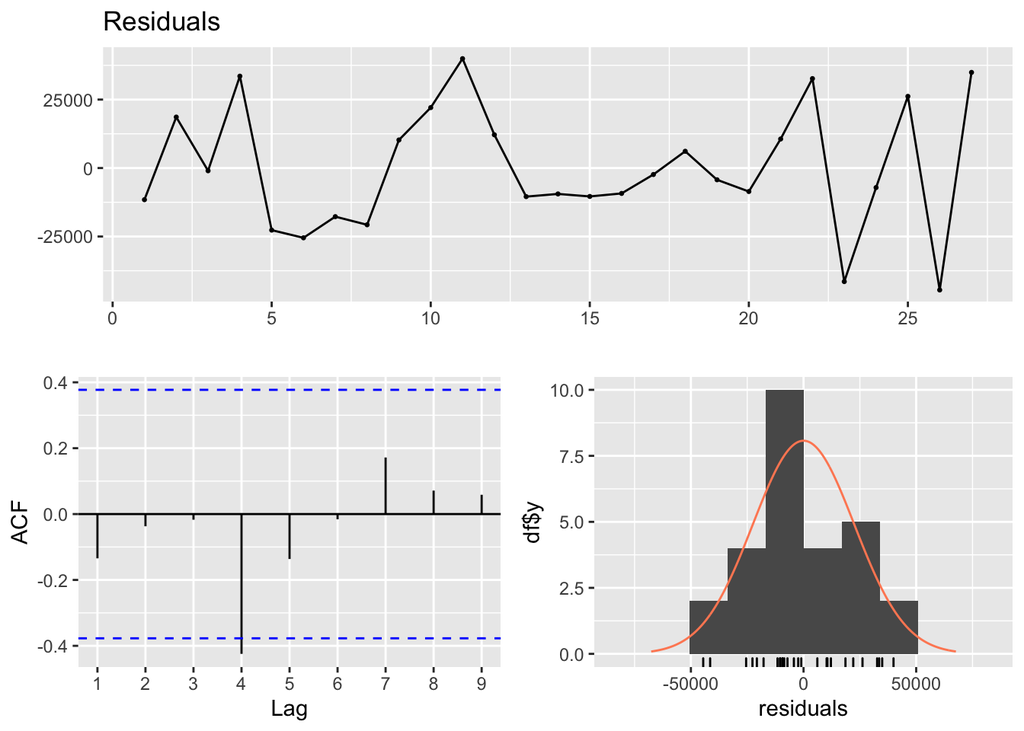

```
##
##  Breusch-Godfrey test for serial correlation of order up to 12
##
## data:  Residuals
## LM test = 20.476, df = 12, p-value = 0.05859
```

```r
checkresiduals(model8)
```

When we look at the ACF of residuals in model-8, we see that the critical value is exceeded slightly at lag-4.

```r
model9 <-lm(Unleaded.Gasoline.Sale..UGS. ~Price.of.Unleaded.Gasoline..PU.+ X..Unleaded.Gasoline.Vehicles..NUGV.+ X..of.Diesel.Gasoline.Vehicles..NDGV.+ quarters+trend_variable+ lag1_UGS+lag4_UGS,tr_data)
summary(model9)
```

```
##
## Call:
## lm(formula = Unleaded.Gasoline.Sale..UGS. ~ Price.of.Unleaded.Gasoline..PU. +
##     X..Unleaded.Gasoline.Vehicles..NUGV. + X..of.Diesel.Gasoline.Vehicles..NDGV. +
##     quarters + trend_variable + lag1_UGS + lag4_UGS, data = tr_data)
##
## Residuals:
##    Min     1Q Median     3Q    Max
## -44972 -15352  -4168  15562  40851
##
## Coefficients:
##                                         Estimate Std. Error t value Pr(>|t|)
## (Intercept)                            3.041e+06  9.061e+05   3.357  0.00470
## Price.of.Unleaded.Gasoline..PU.       -5.819e+02  1.886e+02  -3.086  0.00806
## X..Unleaded.Gasoline.Vehicles..NUGV.  -8.422e-01  3.584e-01  -2.350  0.03396
## X..of.Diesel.Gasoline.Vehicles..NDGV.  1.093e+04  4.010e+03   2.725  0.01644
## quarters2                              1.089e+05  3.370e+04   3.232  0.00602
## quarters3                              3.489e+05  6.209e+04   5.619 6.33e-05
## quarters4                              2.131e+05  5.193e+04   4.104  0.00107
## trend_variable                        -1.063e+04  5.600e+03  -1.898  0.07844
## lag1_UGS                              -4.908e-01  2.236e-01  -2.195  0.04553
## lag4_UGS                              -1.523e-01  2.042e-01  -0.746  0.46796
##
## (Intercept)                           **
## Price.of.Unleaded.Gasoline..PU.       **
## X..Unleaded.Gasoline.Vehicles..NUGV.  *
## X..of.Diesel.Gasoline.Vehicles..NDGV. *
## quarters2                             **
## quarters3                             ***
## quarters4                             **
## trend_variable                        .
## lag1_UGS                              *
## lag4_UGS
## ---
## Signif. codes:  0 '***' 0.001 '**' 0.01 '*' 0.05 '.' 0.1 ' ' 1
##
## Residual standard error: 29430 on 14 degrees of freedom
##   (4 observations deleted due to missingness)
## Multiple R-squared:  0.9656, Adjusted R-squared:  0.9435
## F-statistic: 43.65 on 9 and 14 DF,  p-value: 1.042e-08
```

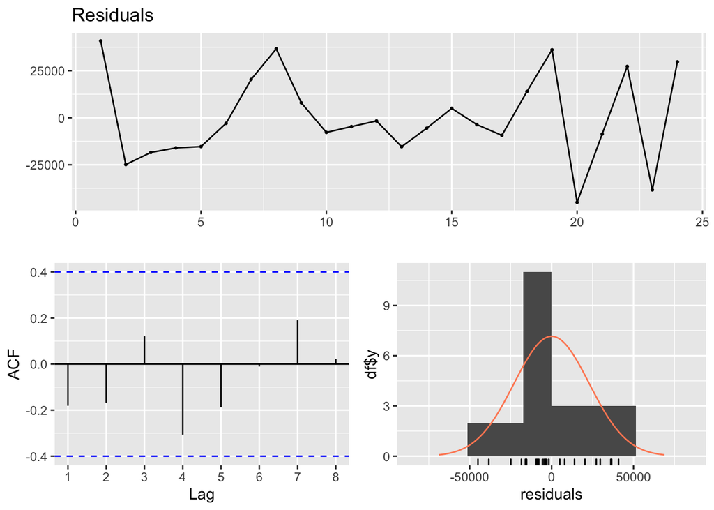

```
##
##  Breusch-Godfrey test for serial correlation of order up to 13
##
## data:  Residuals
## LM test = 22.867, df = 13, p-value = 0.0433
```

```r
checkresiduals(model9)
```

When we analyze the above models, Model-8 is the selected model for the prediction of “2007 Unleaded Gasoline Sales” because of the higher adjusted R-squared value than the others and significance of coefficients. Looking at the p-values of the variables in the model-8, it becomes clear that they are all significant.

### 5. Validity of the Selected Model

```r
best_model<- model8
summary(best_model)
```

```
##
## Call:
## lm(formula = Unleaded.Gasoline.Sale..UGS. ~ Price.of.Unleaded.Gasoline..PU. +
##     X..Unleaded.Gasoline.Vehicles..NUGV. + X..of.Diesel.Gasoline.Vehicles..NDGV. +
##     quarters + trend_variable + lag1_UGS, data = tr_data)
##
## Residuals:
##    Min     1Q Median     3Q    Max
## -44528 -10996  -4285  15377  39939
##
## Coefficients:
##                                         Estimate Std. Error t value Pr(>|t|)
## (Intercept)                            2.796e+06  6.050e+05   4.621 0.000212
## Price.of.Unleaded.Gasoline..PU.       -6.308e+02  1.628e+02  -3.876 0.001108
## X..Unleaded.Gasoline.Vehicles..NUGV.  -7.551e-01  2.011e-01  -3.755 0.001450
## X..of.Diesel.Gasoline.Vehicles..NDGV.  9.724e+03  2.033e+03   4.782 0.000149
## quarters2                              9.041e+04  2.366e+04   3.821 0.001252
## quarters3                              3.099e+05  1.729e+04  17.924 6.33e-13
## quarters4                              1.985e+05  4.069e+04   4.878 0.000121
## trend_variable                        -8.559e+03  3.562e+03  -2.403 0.027253
## lag1_UGS                              -4.865e-01  1.947e-01  -2.499 0.022362
##
## (Intercept)                           ***
## Price.of.Unleaded.Gasoline..PU.       **
## X..Unleaded.Gasoline.Vehicles..NUGV.  **
## X..of.Diesel.Gasoline.Vehicles..NDGV. ***
## quarters2                             **
## quarters3                             ***
## quarters4                             ***
## trend_variable                        *
## lag1_UGS                              *
## ---
## Signif. codes:  0 '***' 0.001 '**' 0.01 '*' 0.05 '.' 0.1 ' ' 1
##
## Residual standard error: 27090 on 18 degrees of freedom
##   (1 observation deleted due to missingness)
## Multiple R-squared:  0.9778, Adjusted R-squared:  0.9679
## F-statistic: 99.11 on 8 and 18 DF,  p-value: 2.71e-13
```

Looking at the p-values of the variables in the selected model, it becomes clear that they are all significant. Also, the R-value of the model (0.9679) is an acceptable value.

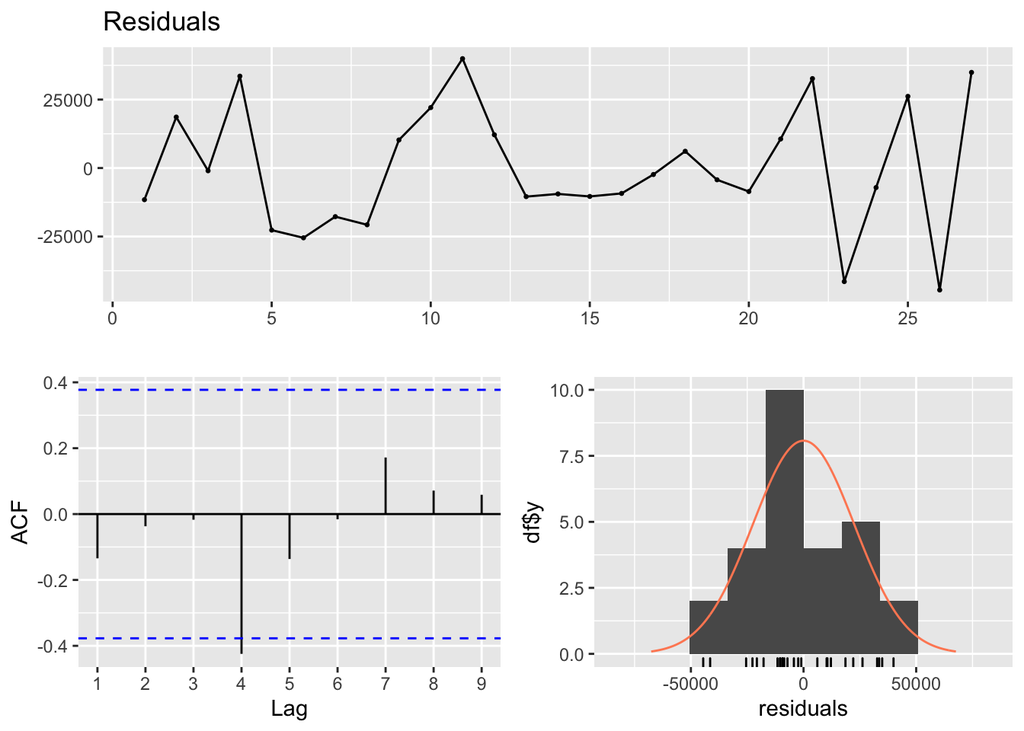

```
##
##  Breusch-Godfrey test for serial correlation of order up to 12
##
## data:  Residuals
## LM test = 20.476, df = 12, p-value = 0.05859
```

```r
checkresiduals(best_model)
```

According to the histogram of the residuals, normal distribution with zero mean and constant variance of the residuals assumption has been satisfied. According to ACF, we see that the critical value is exceeded slightly at lag-4. However, lag4_UGS variable was added to the model-9 and seen that the SSE values and adjusted R-squared value gets worse, it is not decided to be added to the model. So, the autocorrelation of residuals in lag-4 can be ignored due to the small number of data and the sufficiency of the variables in the model to explain unleaded gasoline sales.

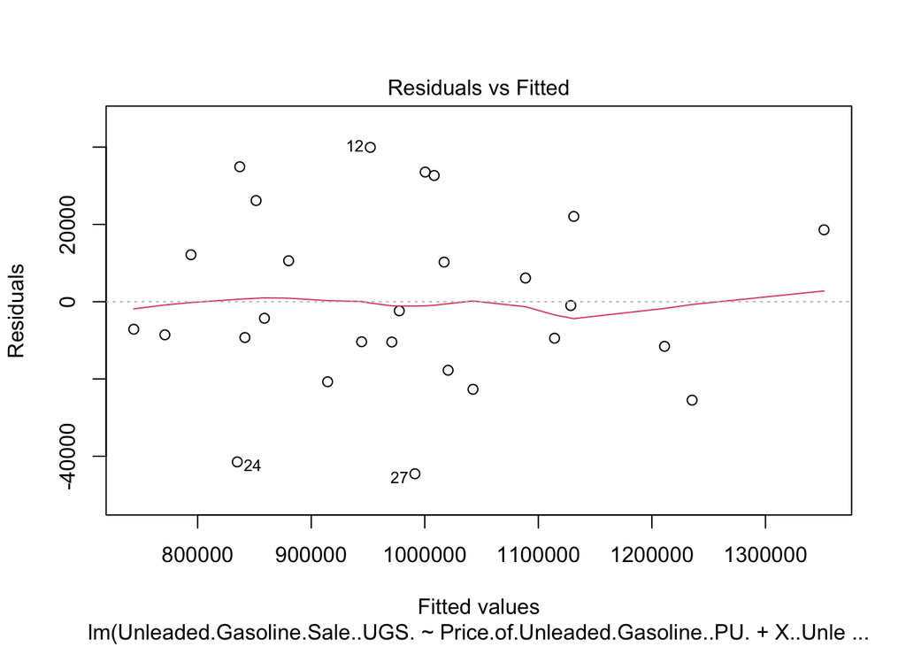

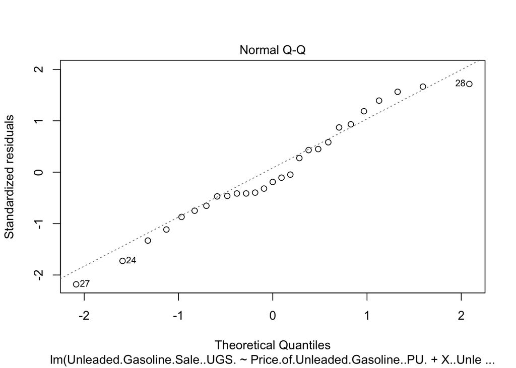

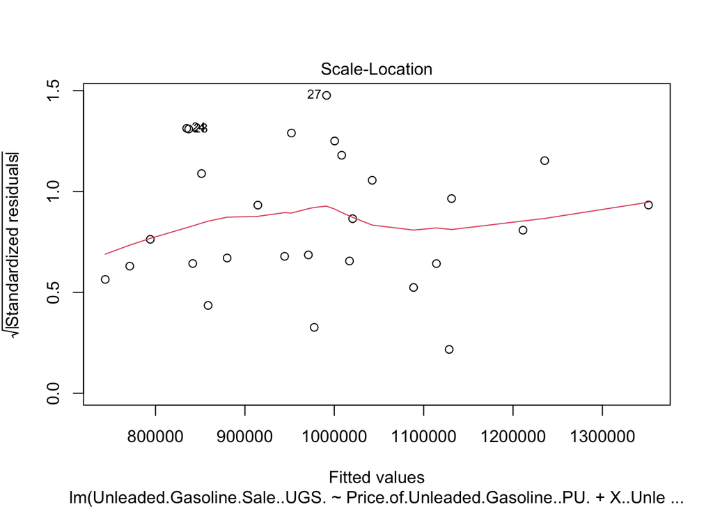

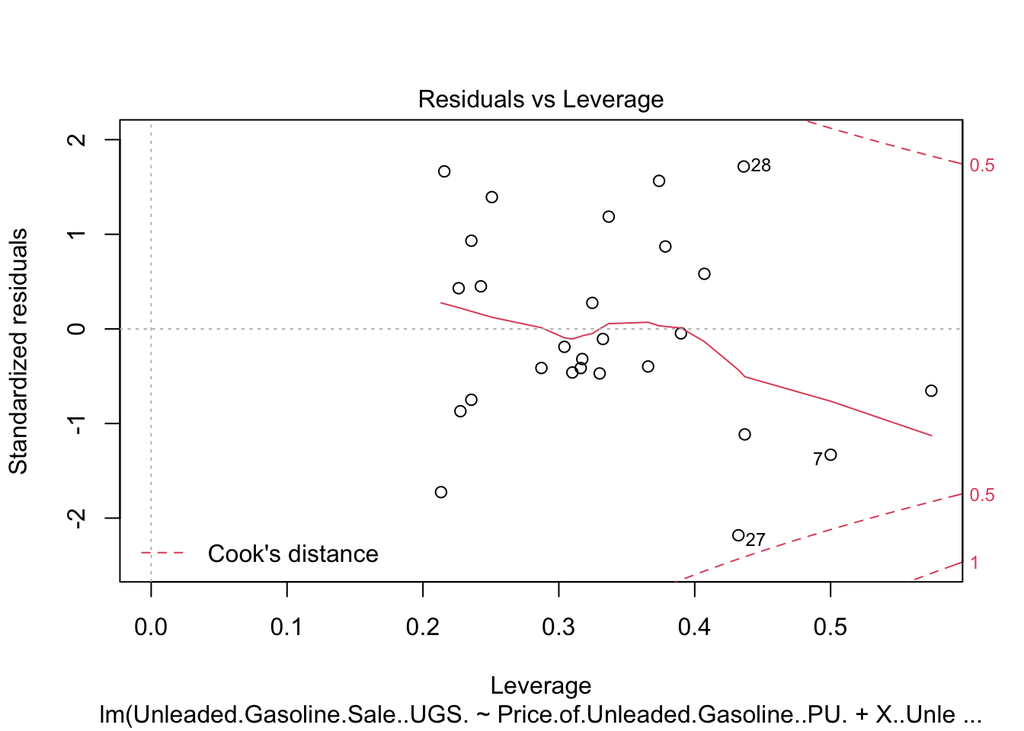

```r
plot(best_model)
```

When we analyze the Normal Q-Q Plot and Residuals vs Fitted Plot, it seems that normality assumption with zero mean and constant variance of the residuals has been satisfied.

### 6. 2007 Unleaded Gasoline Sales Forecast

```r
UGSdata$quarters<-as.character(UGSdata$quarters)
test_data<- UGSdata[c(29,30,31,32),]
prediction=NA
for(i in 1:nrow(test_data)){
     prediction[i] = predict(best_model,newdata=test_data[i,])
    if(i!= 4){
     test_data$lag1_UGS[[i+1]] = prediction[i]
        }
}
prediction
```

```
## [1] 662492.3 845565.1 965974.6 788131.3
```

Predictions= {662492.3, 845565.1, 965974.6, 788131.3}

### 7. Conclusion

Nine models were tried to predict unleaded gasoline sales for 2007. According to adjusted R-squared, residual analysis, significance of coefficients, residuals vs fitted plot and normal Q-Q plot of residuals, model-8 is the best model for prediction. Therefore, the predictions were made based on model-8. Predictions for unleaded gasoline sales for 2007 are {Q1=662492.3, Q2=845565.1, Q3=965974.6, Q4=788131.3}